# Bayesian Homework 4

> Alex Yang - zy7ts homework 4 - Bayesian Hierarchical Modeling

# Problem Statement

The coffee shop chain is investigating how store manager personality traits (conscientiousness and neuroticism) impacts coffee and food sales. The stakeholders are interested in seeing whether coffee and food sales could be impacted differently based on manager personality traits; they are also interested in stores’ performances given constant personality traits.

# Approach

> We will be using a **Bayesian Hierarchical Regression Model** to analyze the data. This model will enable us to account for clustering relationship within the store while accounting for the store managers’ personality traits’ impact on the coffee and food sales

Therefore, we define our model as following:

Where:

- $\beta_0$ = Baseline sales
- $\beta_1$ = effects of the sale being food
- $\beta_2$ = effects of conscientiousness on coffee sales
- $\beta_3$ = effects of neuroticism on coffee sales
- $\beta_4$ = effect of conscientiousness on food sales (on top of coffee sales)
- $\beta_5$ = effect of neuroticism on food sales (on top of coffee sales)
- $sales_ij$ = sales for store j observation i
- $food_ij$ = food vs coffee indicator variable (food =1, coffee = 0)
- $con_i$ = $i_{th}$ store manager’s conscientiousness score
- $neur_i$ = $i_{th}$ store manager’s neuroticism score
- $u_0j$ = store level effects (random intercept)
- $\epsilon_ij$ = residual error for observation i

This model accounts for:

1. clustering effects by the store
2. store manager’s personality traits on sale
3. food vs coffee effects

# Prior Rationale

- Regression coefficients $\beta$ : we use weakly informed priors $Normal(0,1)$ to reflect uncertainty about how the beta variables are going to impact the model
- Variance distribution $u_0j$ : we use Half Cauchy $\text{Half Cauchy}(0,1)$ to account for the potential variability between stores; we also use the same prior to account for the variability in sales

# Findings

## 1. Parameter estimation

Below are the key parameter estimates from the Bayesian hierarchical model:

| Parameter | Estimate | Est. Error | l-95% CI | u-95% CI | Interpretation |
| --- | --- | --- | --- | --- | --- |
| **Intercept (β₀)** | 0.49 | 0.33 | -0.13 | 1.18 | Baseline sales for coffee when personality traits are at their average values. |
| **Food (β₁)** | -0.84 | 0.11 | -1.05 | -0.63 | Food sales are on average lower than coffee sales |
| **Conscientiousness (β₂)** | 0.29 | 0.44 | -0.60 | 1.15 | Positive effect of conscientiousness on coffee sales, though uncertainty remains. |
| **Neuroticism (β₃)** | -0.36 | 0.30 | -0.98 | 0.23 | Negative effect of neuroticism on coffee sales, but with some uncertainty. |
| **Food × Conscientiousness (β₄)** | 0.99 | 0.16 | 0.68 | 1.29 | Strong positive effect of conscientiousness on food sales, offsetting the base coffee effect. |
| **Food × Neuroticism (β₅)** | 0.11 | 0.10 | -0.09 | 0.31 | Neuroticism has a negligible offset effect on food sales relative to coffee sales. |

## 2. Store-level variability

# Summary

## Store performance

As we have discussed in the *Findings* section, there is a high variability across different stores in sales suggesting that there might be external factors that are impacting the sales as well on top of store manager’s personality traits.

The stores performances could be summarized into “average”, “under performing”, and “over performing”; the results could be found below:

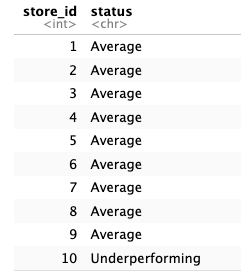

# Diagnostics

## Trace Plots

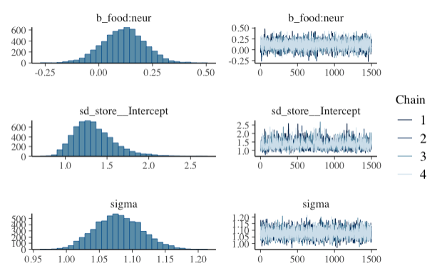

## Posterior Predictive Checks

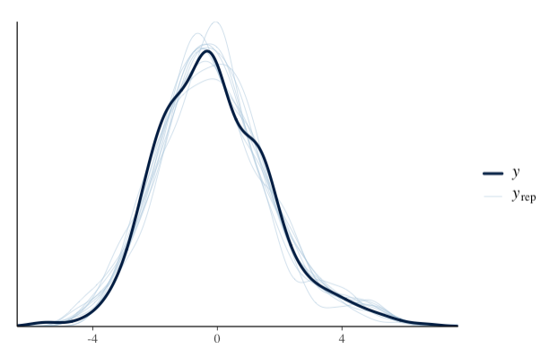

## Store-level Random Effects

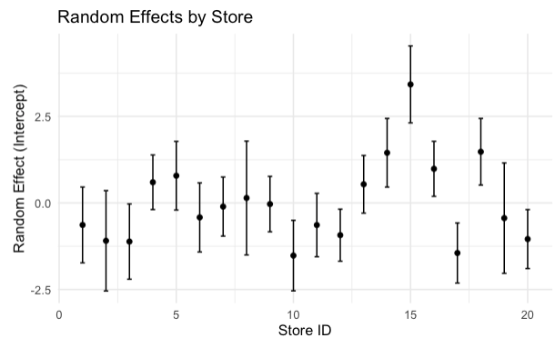

# R Implementation

## Loading Data and Necessary Packages

```r
library(tidyverse)
library(brms)
# Loading data
sales_data <- read.csv("/Users/alexyang/Git/BayesianML/Homework/sales-ds6040.csv")

# Quick overview of data
glimpse(sales_data)
```

```
## Rows: 480
## Columns: 5
## $ sales <dbl> 1.36382057, -1.11974672, -0.18014063, -2.28233382, 0.67330448, -…
## $ food  <int> 0, 1, 0, 1, 0, 1, 0, 1, 0, 1, 0, 1, 0, 1, 0, 1, 0, 1, 0, 1, 0, 1…
## $ con   <dbl> 0.2165529, 0.2165529, 0.2165529, 0.2165529, 0.2165529, 0.2165529…
## $ neur  <dbl> 1.290224, 1.290224, 1.290224, 1.290224, 1.290224, 1.290224, 1.29…
## $ store <int> 0, 0, 0, 0, 0, 0, 0, 0, 0, 0, 0, 0, 0, 0, 0, 0, 0, 0, 0, 0, 0, 0…
```

```r
summary(sales_data)
```

```
##      sales               food          con               neur
##  Min.   :-5.65136   Min.   :0.0   Min.   :-2.0189   Min.   :-2.27649
##  1st Qu.:-1.40581   1st Qu.:0.0   1st Qu.:-0.5713   1st Qu.:-0.86760
##  Median :-0.26580   Median :0.5   Median :-0.2103   Median :-0.09252
##  Mean   :-0.09569   Mean   :0.5   Mean   :-0.2577   Mean   :-0.10995
##  3rd Qu.: 1.08439   3rd Qu.:1.0   3rd Qu.: 0.2390   3rd Qu.: 0.38617
##  Max.   : 6.69181   Max.   :1.0   Max.   : 0.7389   Max.   : 2.38280
##      store
##  Min.   : 0.00
##  1st Qu.: 4.75
##  Median : 9.50
##  Mean   : 9.50
##  3rd Qu.:14.25
##  Max.   :19.00
```

```r
head(sales_data, n=10)
```

```
##          sales food       con     neur store
## 1   1.36382057    0 0.2165529 1.290224     0
## 2  -1.11974672    1 0.2165529 1.290224     0
## 3  -0.18014063    0 0.2165529 1.290224     0
## 4  -2.28233382    1 0.2165529 1.290224     0
## 5   0.67330448    0 0.2165529 1.290224     0
## 6  -2.34991845    1 0.2165529 1.290224     0
## 7  -1.23823233    0 0.2165529 1.290224     0
## 8  -1.57769965    1 0.2165529 1.290224     0
## 9  -0.04587785    0 0.2165529 1.290224     0
## 10 -0.52054369    1 0.2165529 1.290224     0
```

```r
str(sales_data)
```

```
## 'data.frame':    480 obs. of  5 variables:
##  $ sales: num  1.364 -1.12 -0.18 -2.282 0.673 ...
##  $ food : int  0 1 0 1 0 1 0 1 0 1 ...
##  $ con  : num  0.217 0.217 0.217 0.217 0.217 ...
##  $ neur : num  1.29 1.29 1.29 1.29 1.29 ...
##  $ store: int  0 0 0 0 0 0 0 0 0 0 ...
```

```r
# Checking for missing values
colSums(is.na(sales_data))
```

```
## sales  food   con  neur store
##     0     0     0     0     0
```

## Visualize Data

[figure not shown]

```r
# Setting ggplot theme
theme_set(theme_minimal())

# Visualize sales by food type
ggplot(sales_data, aes(x = food, y = sales)) +
  geom_boxplot() +
  labs(title = "Sales by Food Type", x = "Food (0 = Coffee, 1 = Food)", y = "Sales")
```

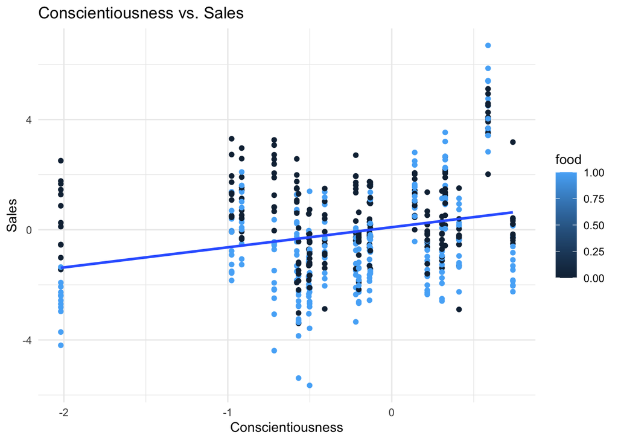

```r
# Scatterplot for Conscientiousness vs. Sales
ggplot(sales_data, aes(x = con, y = sales, color = food)) +
  geom_point() +
  geom_smooth(method = "lm", se = FALSE) +
  labs(title = "Conscientiousness vs. Sales", x = "Conscientiousness", y = "Sales")
```

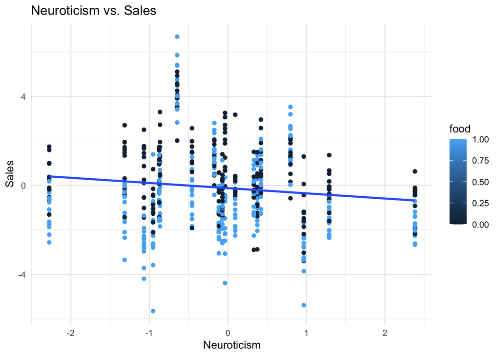

```r
# Scatterplot for Neuroticism vs. Sales
ggplot(sales_data, aes(x = neur, y = sales, color = food)) +
  geom_point() +
  geom_smooth(method = "lm", se = FALSE) +
  labs(title = "Neuroticism vs. Sales", x = "Neuroticism", y = "Sales")
```

## Fit Model with `brms`

```r
# Define the Bayesian hierarchical regression model
formula <- bf(
  sales ~ food + con + neur + con:food + neur:food + (1 | store)
)

# Fitting model with brms
fit_brms <- brm(
  formula = formula,
  data = sales_data,
  prior = c(
    prior(normal(0,1), class = "b"), # priors for fixed effects
    prior(cauchy(0,1), class = "sd"), # prior for random intercepts
    prior(cauchy(0,1), class = "sigma") # prior for residual
  ),
  chains = 4,
  iter = 2000,
  warmup = 500,
  seed = 42,
  cores = 4
)
```

```
## Trying to compile a simple C file
```

[output not shown]

## Summarize the Model

```r
summary(fit_brms)
```

```
##  Family: gaussian
##   Links: mu = identity; sigma = identity
## Formula: sales ~ food + con + neur + con:food + neur:food + (1 | store)
##    Data: sales_data (Number of observations: 480)
##   Draws: 4 chains, each with iter = 2000; warmup = 500; thin = 1;
##          total post-warmup draws = 6000
##
## Multilevel Hyperparameters:
## ~store (Number of levels: 20)
##               Estimate Est.Error l-95% CI u-95% CI Rhat Bulk_ESS Tail_ESS
## sd(Intercept)     1.34      0.24     0.96     1.92 1.00     1548     2500
##
## Regression Coefficients:
##           Estimate Est.Error l-95% CI u-95% CI Rhat Bulk_ESS Tail_ESS
## Intercept     0.49      0.33    -0.13     1.18 1.00     2091     2534
## food         -0.84      0.11    -1.05    -0.63 1.00     5841     4309
## con           0.29      0.44    -0.60     1.15 1.00     2191     2939
## neur         -0.36      0.30    -0.98     0.23 1.00     2645     2928
## food:con      0.99      0.16     0.68     1.29 1.00     5593     4211
## food:neur     0.11      0.10    -0.09     0.31 1.00     5315     3710
##
## Further Distributional Parameters:
##       Estimate Est.Error l-95% CI u-95% CI Rhat Bulk_ESS Tail_ESS
## sigma     1.08      0.04     1.01     1.15 1.00     5683     4153
##
## Draws were sampled using sampling(NUTS). For each parameter, Bulk_ESS
## and Tail_ESS are effective sample size measures, and Rhat is the potential
## scale reduction factor on split chains (at convergence, Rhat = 1).
```

```r
# Extract fixed effects
fixef(fit_brms)
```

```
##             Estimate  Est.Error        Q2.5      Q97.5
## Intercept  0.4934234 0.32846409 -0.13083461  1.1786153
## food      -0.8367934 0.10591189 -1.05272687 -0.6306926
## con        0.2923429 0.44295314 -0.60354046  1.1462280
## neur      -0.3599422 0.30419810 -0.97807821  0.2265044
## food:con   0.9866334 0.15799584  0.67538314  1.2944165
## food:neur  0.1142237 0.09999468 -0.08506482  0.3060033
```

```r
# Extract random effects
ranef(fit_brms)
```

```
## $store
## , , Intercept
##
##       Estimate Est.Error       Q2.5       Q97.5
## 0  -0.63679314 0.5582726 -1.7424182  0.43748307
## 1  -1.09452060 0.7395073 -2.5819750  0.32111625
## 2  -1.11685427 0.5545914 -2.1937811 -0.04661069
## 3   0.59629847 0.4021521 -0.2176503  1.37612248
## 4   0.78571507 0.5056208 -0.2573443  1.76346169
## 5  -0.41848753 0.5093175 -1.4437697  0.56777529
## 6  -0.10646628 0.4352230 -0.9880722  0.74584143
## 7   0.14148696 0.8388408 -1.5567218  1.75871052
## 8  -0.03392208 0.4081776 -0.8487261  0.76717613
## 9  -1.52144278 0.5196515 -2.5546519 -0.50697460
## 10 -0.63939882 0.4667998 -1.5875562  0.23515617
## 11 -0.93188751 0.3833610 -1.6886522 -0.18671657
## 12  0.53769086 0.4247095 -0.3102314  1.35825372
## 13  1.44764598 0.5060045  0.4535439  2.44281419
## 14  3.42315167 0.5665433  2.3112260  4.56197535
## 15  0.98431289 0.4054957  0.1709612  1.77754425
## 16 -1.44667994 0.4429168 -2.3346269 -0.61767516
## 17  1.47688578 0.4911563  0.5063018  2.42605311
## 18 -0.43947704 0.8134708 -2.0399592  1.16183832
## 19 -1.04486638 0.4339861 -1.9056884 -0.21320499
```

```r
# Posterior samples for key parameters
posterior_samples_brms <- posterior_samples(fit_brms)
posterior_summary <- posterior_samples_brms %>%
  summarise(
    mean_b_con = mean(b_con),
    lower_b_con = quantile(b_con, 0.025),
    upper_b_con = quantile(b_con, 0.975)
  )
print(posterior_summary)
```

```
##   mean_b_con lower_b_con upper_b_con
## 1  0.2923429  -0.6035405    1.146228
```

## Store Level Performances

```r
# Extract random effects for stores
store_effects <- ranef(fit_brms)$store[, , "Intercept"]

# Summarize random effects
store_summary <- as_tibble(store_effects) %>%
  mutate(
    store_id = row_number(),
    lower = Estimate - 1.96 * Est.Error,
    upper = Estimate + 1.96 * Est.Error
  )

# Flag overperforming and underperforming stores
store_summary <- store_summary %>%
  mutate(
    status = case_when(
      Estimate > 1.34 ~ "Overperforming",
      Estimate < -1.34 ~ "Underperforming",
      TRUE ~ "Average"
    )
  )

# Print summary
print(store_summary)
```

```
## # A tibble: 20 × 8
##    Estimate Est.Error   Q2.5   Q97.5 store_id  lower   upper status
##       <dbl>     <dbl>  <dbl>   <dbl>    <int>  <dbl>   <dbl> <chr>
##  1  -0.637      0.558 -1.74   0.437         1 -1.73   0.457  Average
##  2  -1.09       0.740 -2.58   0.321         2 -2.54   0.355  Average
##  3  -1.12       0.555 -2.19  -0.0466        3 -2.20  -0.0299 Average
##  4   0.596      0.402 -0.218  1.38          4 -0.192  1.38   Average
##  5   0.786      0.506 -0.257  1.76          5 -0.205  1.78   Average
##  6  -0.418      0.509 -1.44   0.568         6 -1.42   0.580  Average
##  7  -0.106      0.435 -0.988  0.746         7 -0.960  0.747  Average
##  8   0.141      0.839 -1.56   1.76          8 -1.50   1.79   Average
##  9  -0.0339     0.408 -0.849  0.767         9 -0.834  0.766  Average
## 10  -1.52       0.520 -2.55  -0.507        10 -2.54  -0.503  Underperforming
## 11  -0.639      0.467 -1.59   0.235        11 -1.55   0.276  Average
## 12  -0.932      0.383 -1.69  -0.187        12 -1.68  -0.180  Average
## 13   0.538      0.425 -0.310  1.36         13 -0.295  1.37   Average
## 14   1.45       0.506  0.454  2.44         14  0.456  2.44   Overperforming
## 15   3.42       0.567  2.31   4.56         15  2.31   4.53   Overperforming
## 16   0.984      0.405  0.171  1.78         16  0.190  1.78   Average
## 17  -1.45       0.443 -2.33  -0.618        17 -2.31  -0.579  Underperforming
## 18   1.48       0.491  0.506  2.43         18  0.514  2.44   Overperforming
## 19  -0.439      0.813 -2.04   1.16         19 -2.03   1.15   Average
## 20  -1.04       0.434 -1.91  -0.213        20 -1.90  -0.194  Average
```

```r
# Print out store-level performance and its ID
store_performance <- store_summary |>
  select(c('store_id','status'))

print(store_performance)
```

```
## # A tibble: 20 × 2
##    store_id status
##       <int> <chr>
##  1        1 Average
##  2        2 Average
##  3        3 Average
##  4        4 Average
##  5        5 Average
##  6        6 Average
##  7        7 Average
##  8        8 Average
##  9        9 Average
## 10       10 Underperforming
## 11       11 Average
## 12       12 Average
## 13       13 Average
## 14       14 Overperforming
## 15       15 Overperforming
## 16       16 Average
## 17       17 Underperforming
## 18       18 Overperforming
## 19       19 Average
## 20       20 Average
```

## Diagnostics

### Trace Plots

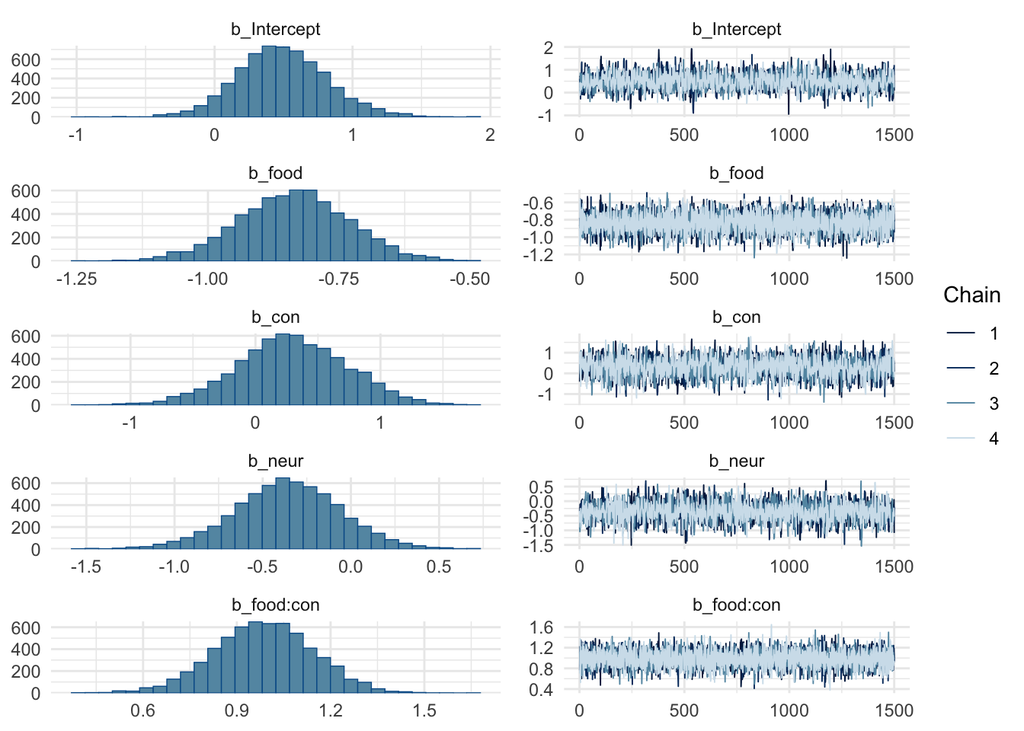

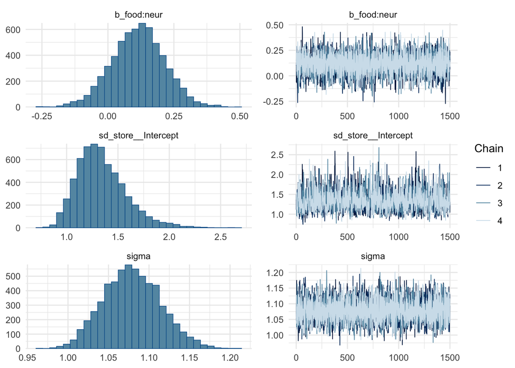

```r
plot(fit_brms)
```

### Posterior Predictive Checks

```r
pp_check(fit_brms)
```

```
## Using 10 posterior draws for ppc type 'dens_overlay' by default.
```

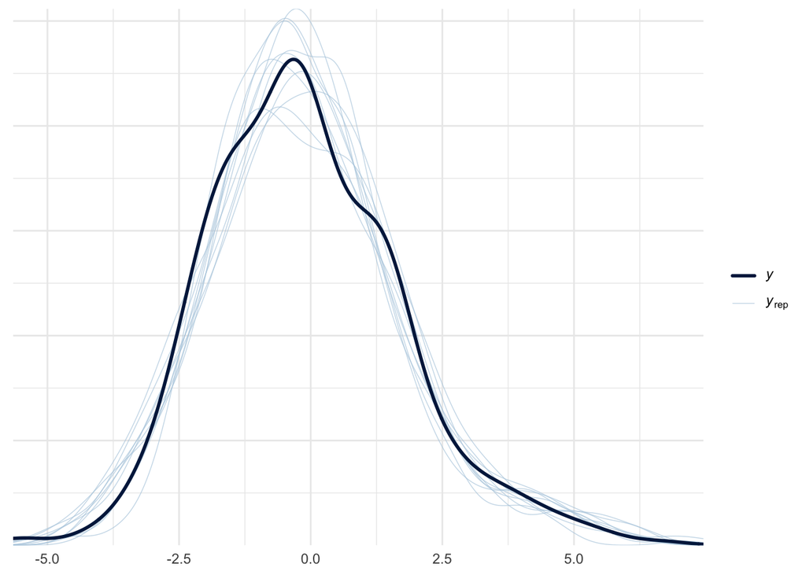

```r
# graph suggests the model has a pretty good fit
```

### Store-level Random Effects

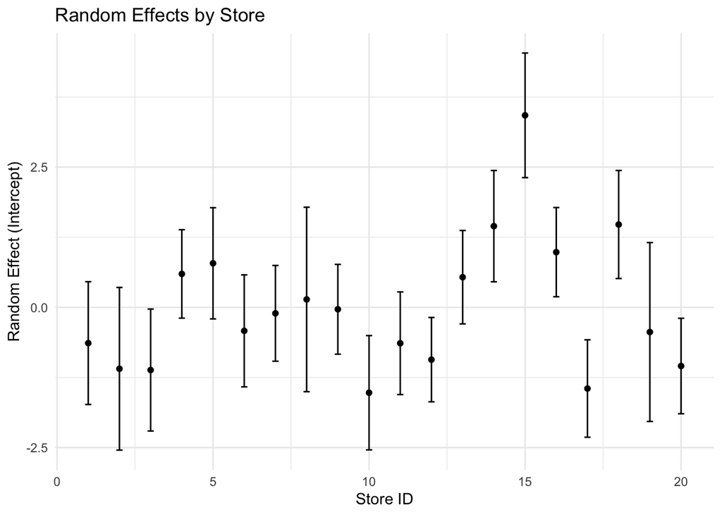

```r
# Visualize random intercepts by store
ranef_store <- ranef(fit_brms)$store[, , "Intercept"]
store_summary <- as_tibble(ranef_store) %>%
  mutate(store_id = row_number(), lower = Estimate - 1.96 * Est.Error, upper = Estimate + 1.96 * Est.Error)

ggplot(store_summary, aes(x = store_id, y = Estimate)) +
  geom_point() +
  geom_errorbar(aes(ymin = lower, ymax = upper), width = 0.2) +
  labs(title = "Random Effects by Store", x = "Store ID", y = "Random Effect (Intercept)") +
  theme_minimal()
```